# Working with microsecond time-series

### Building the Consolidated Tape

Now that we have cleaned the data for both venues (Madrid and CBOE Europe), we need to combine them into a single view of the market. This is often called a **Consolidated Tape**.

**The Challenge: Asynchronous Data** Financial markets are *asynchronous*. A trade happens on BME at `t=100`, and a trade happens on CBOE at `t=105`. They never align perfectly.

If we just join them, we will have gaps (NaNs). To solve this, we use the **Last Traded Price (LTP)** logic:

> *"If a trade didn't happen on this venue at this exact microsecond, the valid price is still the price of the **last** trade that did happen."*

**The Solution:**

1. **Concat & Sort:** Put all trades in one long list sorted by time.
2. **Pivot:** Create columns for each venue (`XMAD`, `CEUX`).
3. **Forward Fill (`ffill`):** This is the magic step. It propagates the last known valid observation forward to the next valid index.

```python
# 1. Combine
tape_full = pd.concat([df_xmad_full, df_ceux_full])
tape_full.sort_index(inplace=True)

# 2. Pivot
# Now strict uniqueness is guaranteed, so pivot works perfectly
tape_pivot = tape_full.pivot(columns='mic', values='px')

# 3. Fill Forward
# This propagates the last valid price to the nanosecond level
consolidated_tape = tape_pivot.ffill()

print(f"Total Updates in Tape: {len(consolidated_tape)}")
print(consolidated_tape.head())
```

```
Total Updates in Tape: 25337
mic                            CEUX   XMAD
ts
2025-11-07 08:00:17.000449000   NaN  8.985
2025-11-07 08:00:17.000449001   NaN  8.985
2025-11-07 08:00:17.000449002   NaN  8.985
2025-11-07 08:00:17.000449003   NaN  8.985
2025-11-07 08:00:17.000449004   NaN  8.985
```

| mic ts | CEUX | XMAD | spread |
| --- | --- | --- | --- |
| 2025-11-07 08:00:17.000449000 | NaN | 8.985 | NaN |
| 2025-11-07 08:00:17.000449001 | NaN | 8.985 | NaN |
| 2025-11-07 08:00:17.000449002 | NaN | 8.985 | NaN |
| 2025-11-07 08:00:17.000449003 | NaN | 8.985 | NaN |
| 2025-11-07 08:00:17.000449004 | NaN | 8.985 | NaN |
| ... | ... | ... | ... |
| 2025-11-07 16:36:15.093153003 | 8.849 | 8.849 | 0.0 |
| 2025-11-07 16:36:15.093153004 | 8.849 | 8.849 | 0.0 |
| 2025-11-07 16:36:15.093153005 | 8.849 | 8.849 | 0.0 |
| 2025-11-07 16:36:15.093153006 | 8.849 | 8.849 | 0.0 |
| 2025-11-07 16:36:15.093153007 | 8.849 | 8.849 | 0.0 |

25337 rows × 3 columns

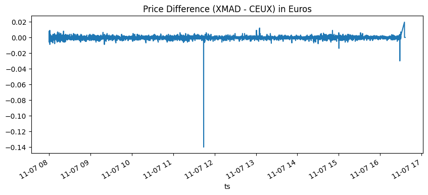

```python
# Instant Vectorized Calculation
consolidated_tape['spread'] = consolidated_tape['XMAD'] - consolidated_tape['CEUX']
display(consolidated_tape)
# Visualize the discrepancy
consolidated_tape['spread'].plot(title="Price Difference (XMAD - CEUX) in Euros", figsize=(10, 4))
```

### Merging Low-Frequency Data (News) with High-Frequency Data (Trades)

We often need to enrich our trade data with external events (News, Macro announcements, Tweets). However, we face a major problem: **Timestamp Mismatch**.

- **News arrives at:** `11:40:00.000000`
- **Trade happens at:** `11:40:00.005231`

A standard SQL-style `left_join` or pandas `merge` requires an **exact match**. Since the timestamps rarely match down to the microsecond, a standard merge would result in almost all data being lost.

**The Solution: `merge_asof`** Pandas `merge_asof` allows for **inexact matches**. It tells the computer:

> *"For every trade, look **backwards** in time and find the most recent news headline that appeared before this trade."*
- **`direction='backward'`**: Ensures we avoid "look-ahead bias." We only tag a trade with news that was already public when the trade occurred.

```python
# 1. Create the News Dataframe
news_data = pd.DataFrame([
    {'ts': '2025-11-07 11:00:00', 'headline': 'Market Open', 'sentiment': 'NEUTRAL'},
    {'ts': '2025-11-07 11:40:00', 'headline': 'RUMOR: Acquisition Talks', 'sentiment': 'POSITIVE'},
    {'ts': '2025-11-07 12:10:00', 'headline': 'CORRECTION: Rumor Denied', 'sentiment': 'NEGATIVE'}
])

# Convert news time to datetime
news_data['ts'] = pd.to_datetime(news_data['ts'])
news_data.sort_values('ts', inplace=True)
display(news_data)
```

|  | ts | headline | sentiment |
| --- | --- | --- | --- |
| 0 | 2025-11-07 11:00:00 | Market Open | NEUTRAL |
| 1 | 2025-11-07 11:40:00 | RUMOR: Acquisition Talks | POSITIVE |
| 2 | 2025-11-07 12:10:00 | CORRECTION: Rumor Denied | NEGATIVE |

```python
# Reset index slightly to make 'ts' a column for merging
tape_reset = consolidated_tape.reset_index()

# Perform the As-Of Merge
tagged_trades = pd.merge_asof(
    tape_reset,             # Left Table (High Frequency - Trades)
    news_data,              # Right Table (Low Frequency - News)
    on='ts',                # The Time Column
    direction='backward'    # Look into the past, never the future!
)



display(tagged_trades)
```

|  | ts | CEUX | XMAD | spread | headline | sentiment |
| --- | --- | --- | --- | --- | --- | --- |
| 0 | 2025-11-07 08:00:17.000449000 | NaN | 8.985 | NaN | NaN | NaN |
| 1 | 2025-11-07 08:00:17.000449001 | NaN | 8.985 | NaN | NaN | NaN |
| 2 | 2025-11-07 08:00:17.000449002 | NaN | 8.985 | NaN | NaN | NaN |
| 3 | 2025-11-07 08:00:17.000449003 | NaN | 8.985 | NaN | NaN | NaN |
| 4 | 2025-11-07 08:00:17.000449004 | NaN | 8.985 | NaN | NaN | NaN |
| ... | ... | ... | ... | ... | ... | ... |
| 25332 | 2025-11-07 16:36:15.093153003 | 8.849 | 8.849 | 0.0 | CORRECTION: Rumor Denied | NEGATIVE |
| 25333 | 2025-11-07 16:36:15.093153004 | 8.849 | 8.849 | 0.0 | CORRECTION: Rumor Denied | NEGATIVE |
| 25334 | 2025-11-07 16:36:15.093153005 | 8.849 | 8.849 | 0.0 | CORRECTION: Rumor Denied | NEGATIVE |
| 25335 | 2025-11-07 16:36:15.093153006 | 8.849 | 8.849 | 0.0 | CORRECTION: Rumor Denied | NEGATIVE |
| 25336 | 2025-11-07 16:36:15.093153007 | 8.849 | 8.849 | 0.0 | CORRECTION: Rumor Denied | NEGATIVE |

25337 rows × 6 columns

```python
tagged_trades.set_index("ts",inplace=True)
tagged_trades.head()
```

| ts | CEUX | XMAD | spread | headline | sentiment |
| --- | --- | --- | --- | --- | --- |
| 2025-11-07 08:00:17.000449000 | NaN | 8.985 | NaN | NaN | NaN |
| 2025-11-07 08:00:17.000449001 | NaN | 8.985 | NaN | NaN | NaN |
| 2025-11-07 08:00:17.000449002 | NaN | 8.985 | NaN | NaN | NaN |
| 2025-11-07 08:00:17.000449003 | NaN | 8.985 | NaN | NaN | NaN |
| 2025-11-07 08:00:17.000449004 | NaN | 8.985 | NaN | NaN | NaN |

```python
tagged_trades
```

| ts | CEUX | XMAD | spread | headline | sentiment |
| --- | --- | --- | --- | --- | --- |
| 2025-11-07 08:00:17.000449000 | NaN | 8.985 | NaN | NaN | NaN |
| 2025-11-07 08:00:17.000449001 | NaN | 8.985 | NaN | NaN | NaN |
| 2025-11-07 08:00:17.000449002 | NaN | 8.985 | NaN | NaN | NaN |
| 2025-11-07 08:00:17.000449003 | NaN | 8.985 | NaN | NaN | NaN |
| 2025-11-07 08:00:17.000449004 | NaN | 8.985 | NaN | NaN | NaN |
| ... | ... | ... | ... | ... | ... |
| 2025-11-07 16:36:15.093153003 | 8.849 | 8.849 | 0.0 | CORRECTION: Rumor Denied | NEGATIVE |
| 2025-11-07 16:36:15.093153004 | 8.849 | 8.849 | 0.0 | CORRECTION: Rumor Denied | NEGATIVE |
| 2025-11-07 16:36:15.093153005 | 8.849 | 8.849 | 0.0 | CORRECTION: Rumor Denied | NEGATIVE |
| 2025-11-07 16:36:15.093153006 | 8.849 | 8.849 | 0.0 | CORRECTION: Rumor Denied | NEGATIVE |
| 2025-11-07 16:36:15.093153007 | 8.849 | 8.849 | 0.0 | CORRECTION: Rumor Denied | NEGATIVE |

25337 rows × 5 columns

```python
# Let's check the result of the merge_asof
tagged_trades.between_time("11:39:40","11:40:05")
```

| ts | CEUX | XMAD | spread | headline | sentiment |
| --- | --- | --- | --- | --- | --- |
| 2025-11-07 11:39:41.318720 | 8.8340 | 8.835 | 0.0010 | Market Open | NEUTRAL |
| 2025-11-07 11:39:54.508561 | 8.8345 | 8.835 | 0.0005 | Market Open | NEUTRAL |
| 2025-11-07 11:39:54.964038 | 8.8345 | 8.833 | -0.0015 | Market Open | NEUTRAL |
| 2025-11-07 11:40:00.802947 | 8.8340 | 8.833 | -0.0010 | RUMOR: Acquisition Talks | POSITIVE |
| 2025-11-07 11:40:00.803186 | 8.8340 | 8.833 | -0.0010 | RUMOR: Acquisition Talks | POSITIVE |

### Performance: Loops vs. Vectorization

In High-Frequency Trading, efficiency is everything. When working with Python, you will often hear: **"Never use loops."**

- **Iterrows (The Loop):** Python processes rows one by one. It has to check the data type, find the memory address, and compute the value for *every single row*. This is incredibly slow for millions of trades.
- **Vectorization (The Numpy Way):** Pandas is built on top of **NumPy**, which is written in C. When you do `df['px'] * df['qty']`, the operation is pushed down to the C-level, processing the entire array of memory at once.

Below, we will demonstrate the massive speed difference between the two approaches.

```python
# The Slow Way (Iterrows)
# NEVER DO THIS IN PRODUCTION
import time

start = time.time()
notionals = []
# We'll only do the first 1000 to save time for the demo
for index, row in tape_full.iloc[:1000].iterrows():
    notionals.append(row['px'] * row['qty'])
end = time.time()

print(f"Looping took: {(end-start):.5f} seconds (for just 1000 rows)")
```

```
Looping took: 0.02809 seconds (for just 1000 rows)
```

```python
# 🐇 The Fast Way (Vectorization)
# Operate on the whole column array at once

start = time.time()

tape_full['notional_eur'] = tape_full['px'] * tape_full['qty']

end = time.time()
print(f"Vectorization took: {(end-start):.5f} seconds (for ALL rows!)")

# Check the math
tape_full[['px', 'qty', 'notional_eur']].head()
```

```
Vectorization took: 0.00100 seconds (for ALL rows!)
```

| ts | px | qty | notional_eur |
| --- | --- | --- | --- |
| 2025-11-07 08:00:17.000449000 | 8.985 | 73 | 655.905 |
| 2025-11-07 08:00:17.000449001 | 8.985 | 607 | 5453.895 |
| 2025-11-07 08:00:17.000449002 | 8.985 | 1 | 8.985 |
| 2025-11-07 08:00:17.000449003 | 8.985 | 11 | 98.835 |
| 2025-11-07 08:00:17.000449004 | 8.985 | 60 | 539.100 |

### Market Microstructure: Filtering "Dirty" Trades

Not all trades in a file represent the "current market price."

- **Lit Order Book (CLOB):** Trades that happen automatically by matching buyers and sellers in the public queue. These form the price.
- **Off-Book / OTC:** Large trades negotiated privately (e.g., over the phone) and reported to the exchange later.

**Why filter Off-Book trades?** Off-book trades might be reported minutes or hours after they were actually agreed upon. If we include them in our time-series, they might appear as massive price spikes (outliers) because they represent a price from the past, not the current millisecond.

We use **MMT Flags** (Market Model Typology) to identify these. Specifically, flags starting with `4` usually indicate "Off-Book" prints.

```python
# 1. Inspect the flags
print("Unique MMT Flags:", tape_full['mmt_flags'].unique())

# 2. Define the "Bad" Condition
# MMT Flag starts with '4' means Off-Book
# We use .str accessor for vectorized string operations
mask_off_book = tape_full['mmt_flags'].str.startswith('4')

# 3. Apply the Filter (Keep what is NOT off-book)
clean_tape = tape_full[~mask_off_book]

print(f"Original Row Count: {len(tape_full)}")
print(f"Clean Row Count:    {len(clean_tape)}")
print(f"Removed {len(tape_full) - len(clean_tape)} noise trades.")
```

```
Unique MMT Flags: ['1O-------P----' '1O-------PH---' '12-------PH---' '5P--------H---'
 '12-------P----' '12--------H---' '12------------' '32D---S---H---'
 '5P------------' '32D---S-------' '32D---S--P----' '32D---S--PH---'
 '45-1----QP----' '45-3-----P----' '45-3----MT----' '12D-----------'
 '32D-------H---' '1K-------PH---' '1K-------P----' '54------------'
 '54--------H---']
Original Row Count: 25337
Clean Row Count:    25331
Removed 6 noise trades.
```

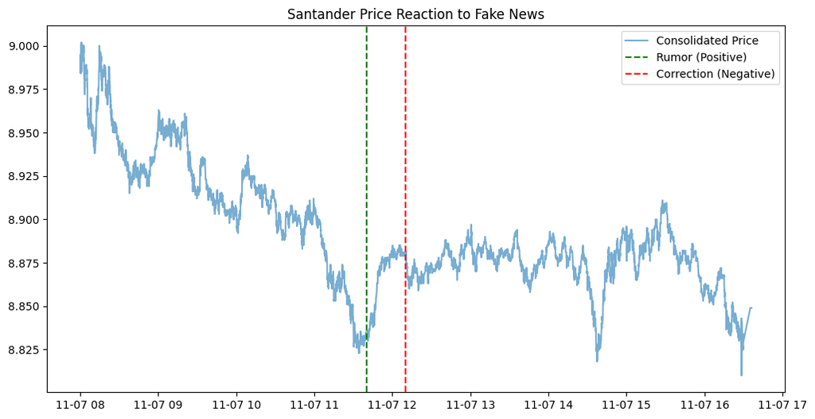

```python
import matplotlib.pyplot as plt

# Plotting the Clean Tape Price
plt.figure(figsize=(12, 6))
plt.plot(clean_tape.index, clean_tape['px'], label='Consolidated Price', alpha=0.6)

# Add vertical lines for our News events
plt.axvline(pd.Timestamp('2025-11-07 11:40:00'), color='green', linestyle='--', label='Rumor (Positive)')
plt.axvline(pd.Timestamp('2025-11-07 12:10:00'), color='red', linestyle='--', label='Correction (Negative)')

plt.title("Santander Price Reaction to Fake News")
plt.legend()
plt.show()
```

### Plotting the pivot table

Since we have our pivot table with the prices of XMAD and CBOE together with the corresponding labels, we can use it to plot it

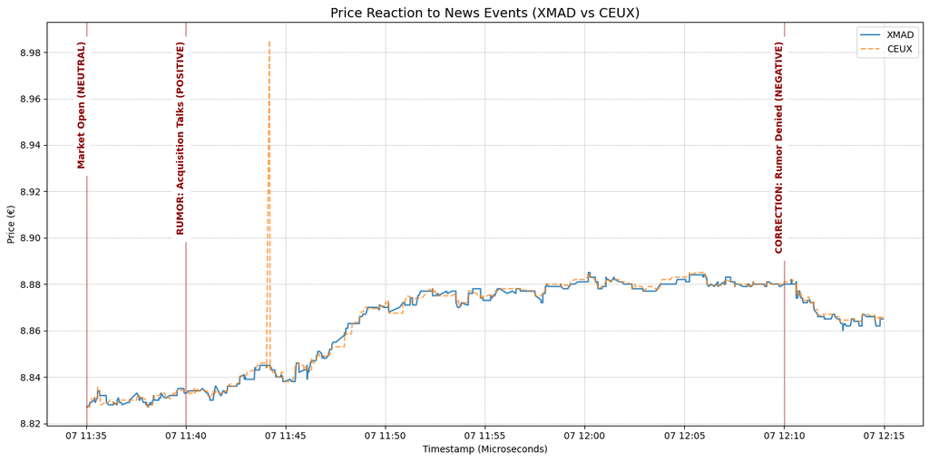

```python
import matplotlib.pyplot as plt


tagged_trades = tagged_trades.between_time("11:35","12:15").copy()

# Create the figure and axis
plt.figure(figsize=(14, 7))

# 1. Plot Prices from both venues
# We plot both to see if arbitrage opportunities (gaps) open up during news events
plt.plot(tagged_trades.index, tagged_trades['XMAD'], label='XMAD', linewidth=1.5, alpha=0.9)
plt.plot(tagged_trades.index, tagged_trades['CEUX'], label='CEUX', linewidth=1.5, alpha=0.7, linestyle='--')

# 2. Identify where the headline changes
# We check where the 'headline' column value is different from the previous row.
# This recovers the exact moment our merge_asof "switched" to a new news item.
headline_changes = tagged_trades[tagged_trades['headline'] != tagged_trades['headline'].shift()]

# 3. Annotate the plot
# We get the max price to position the text labels at the top of the chart
y_max = tagged_trades[['XMAD', 'CEUX']].max().max()

for ts, row in headline_changes.iterrows():
    # Vertical line for the event
    plt.axvline(x=ts, color='firebrick', linestyle='-', alpha=0.4)

    # Text annotation
    label_text = f" {row['headline']} ({row['sentiment']})"

    plt.text(x=ts, y=y_max, s=label_text,
             rotation=90,
             verticalalignment='top',
             horizontalalignment='right', # Right align so text is to the left of the line (looking back)
             fontsize=10,
             color='darkred',
             fontweight='bold',
             backgroundcolor='white') # White background to make text readable over grid lines

# Final Formatting
plt.title("Price Reaction to News Events (XMAD vs CEUX)", fontsize=14)
plt.ylabel("Price (€)")
plt.xlabel("Timestamp (Microseconds)")
plt.legend(loc='best')
plt.grid(True, which='both', linestyle='--', linewidth=0.5)

plt.tight_layout()
plt.show()
```